# RegressionInR: Exercise 1 Bivariate model

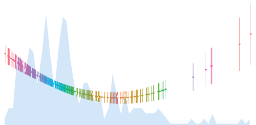

## Todd Combs

26 May, 2018

# Inequality & income in St. Louis neighborhoods

## Introduction

You are interested in economic inequality in St. Louis neighborhoods. You posit that wealthier neighborhoods are more unequal than poorer ones. Here you will investigate the relationship between income inequality and income in St. Louis.

## Step 1: Download data

Go to Social Explorer and download two variables at the census tract level for St. Louis City and St. Louis County: the Gini index of inequality, `SE_T057_001`, and median household income, `SE_T157_001`. Use the 2016 five-year estimates from the American Community Survey.

Formally state your hypothesis.

Read the data into R. Load only the libraries that you need.

## Step 2: Data management

Keep only the variables for tract FIPS code, Tract name, County, Gini index, and median household income. Rename variables with descriptive names and recode income into units of $10,000s.

## Step 3: Visualize data

Create visualizations of each of the two variables separately, then plot the two together to visualize the relationship. Interpret the plots. Are the distributions approximately normal? What is the relationship? Is it linear? What else can you say about each plot?

## Step 4: Bivariate OLS model

Model inequality (Y) on income (X). First run a level-level model. Second, try a model with the natural log of income. Finally, try a model with a quadratic form of income. Discuss the GOF for each model and the statistical significance of the coefficient(s). Which model is best?

## Step 5: Model diagnostics

Check the model for heteroskedasticity visually and with a test statistic. Interpret the plot. Should you reject or fail to reject the null hypothesis of the Breush Pagan test? Wait, what is the null hypothesis? HINT: you may want to ask for the standard errors of the predictions to save time later, on Step 7.

If you decided on the level-level or level-log model, check for linearity of income (or the log of income) with the model predictions. Do this with a plot. Interpret the plot. If you chose the quadratic model, plot the quadratic relationship. Hint: Google ggplot geom_smooth quadratic to find the code/formula to do this. Interpret the plot.

## Step 6: Model results

Present the model results in a table or graph. Interpret everything you should interpret. Should you accept your alternative hypothesis or reject it?

## Step 7: Visualize predictions

Using points and error bars to plot median household income (in $10,000s) by the predicted values of the Gini index for St. Louis neighborhoods. Interpret the plot. Where are you most confident in the predictions? Least confident? What does this say about inequality and income in St. Louis?